# heavy mental

2021/02/22

# Table 1

## Characteristic of Current Wheeze in Study Participants

| Characteristics | Control.subjects | Current.wheeze |
| --- | --- | --- |
| N (%) | 11,767 | 2,121 |
| Age, years | 45.3-46.1 | 46.2-47.0* |
| Female gender | 5915 (50.4) | 1135 (54.3)** |
| Race |  |  |
| Non-Hispanic White | 4834 (66.9) | 1056 (70.8)** |
| Mexican American | 2107 (9.4) | 213 (5.1) |
| Other Hispanic | 1313 (5.8) | 195 (4.7) |
| Non-Hispanic Black | 2419 (10.6) | 519 (13.1) |
| Other | 1104 (7.3) | 138 (6.2) |
| Had health insurance coverage | 8666 (79.1) | 1600 (79.0) |
| Annual household income ≥ $20,000 | 8925 (86.4) | 1380 (77.8)** |
| Smoking status |  |  |
| Never/former smoker | 9481 (81.5) | 1261 (59.0)** |
| Current smoker | 2286 (18.5) | 860 (41.0) |
| Body mass index | 28.3-28.5 | 30.3-30.7** |
| Serum cotinine level, ng/mL | 48.3-53.5 | 107.3-117.5** |
| Family history of asthma | 1797 (15.6) | 738 (34.3) ** |
| Vitamin D insufficiency (<30 ng/mL) | 7894 (62.2) | 1468 (67.6)** |
| Use oral or inhaled steroid in past 2 days | 121 (1.3) | 339 (19.9)** |
| Occupation exposure to mineral dusts or exhaust fumes | 4238 (36.7) | 1081 (50.0)** |
| Serum level of heavy metals, mg/L |  |  |
| Cadmium | 0.46-0.48 | 0.78-0.86** |
| Lead | 1.50-1.58 | 1.60-1.70* |
| Lung function |  |  |
| Percent Predicted FEV1 | 98.5-99.1 | 87.9-89.1** |
| Percent predicted FVC | 101.9-102.3 | 96.2-97.2** |
| Percent predicted FEV1/FVC | 96.4-96.6 | 90.4-91.2** |
| Fractional exhaled nitric oxide (FeNO), ppb | 16.4-17.0 | 20.3-21.9** |

**Description:**

Table 1 shows the main characteristics of the 13,888 study participants with current wheeze and never wheeze. We use stars to show the level of significance. * P < .05 and ** P < .01 for the comparison of subjects with current wheeze and never wheeze.

Compared with the 11,767 control subjects, the 2,121 subjects with current wheeze were more likely to be older, female, non-Hispanic white, current smokers, and users of oral or inhaled steroids in the previous 2 days; and to have a household income less than $20,000, a family history of asthma, vitamin D insufficiency, occupational exposure to mineral dusts or exhaust fumes, a higher BMI, a higher serum cotinine level, higher levels of serum cadmium and lead, a higher FeNO, and lower FEV1, FVC, and FEV1/FVC.

## The Process of Getting Table 1

#### Firstly we use svydesign function which specify a complex survey design to clear the data, recode the index and have a general understanding of it.

**Take the index about health insurance coverage as an example.**

```r
#example:insurance coverage
#table(data1$HIQ011)
tmp_blood$HIQ011[which(tmp_blood$HIQ011 == 9)] <- NA
tmp_blood$HIQ011[which(tmp_blood$HIQ011 == 7)] <- NA
tmp_blood$HIQ011[which(tmp_blood$HIQ011 == 2)] <- 0
# recode insurance converage
tmp_blood$HIQ011 <- as.factor(as.character(tmp_blood$HIQ011))
#The svydesign object combines a data frame and all the survey design information needed to analyse it. These objects are used by the survey modelling and summary functions.
design.WTMEC2YR <- svydesign(ids = ~SDMVPSU, strata = ~SDMVSTRA, weights = ~WTMEC5YR, nest = TRUE, data = tmp_blood)
dsub <- subset(design.WTMEC2YR, ((tmp_blood$RIDAGEYR >= 20)
                                 & (tmp_blood$RIDAGEYR <= 79)
                                 & (!is.na(tmp_blood$asthma))
                                 & (!is.na(tmp_blood$LBXBCD))
                                 & (!is.na(tmp_blood$LBXBPB))))
data1 <- tmp_blood[which((tmp_blood$RIDAGEYR >= 20)
                         & (tmp_blood$RIDAGEYR <= 79)
                         & (!is.na(tmp_blood$asthma))
                         & (!is.na(tmp_blood$LBXBCD))
                         & (!is.na(tmp_blood$LBXBPB))), ]

#table(data1$HIQ011[which(data1$asthma == 0)])
#table(data1$HIQ011[which(data1$asthma == 1)])

tbl <- svytable(~ asthma + HIQ011, dsub)
```

#### In addition, we use svymean and svyttest function to compute the means, variances, ratios and totals for the complex surveys’s data.

**Take the index about lung function as an example.**

```r
library(sjPlot)
# pp FEV1/FVC
#svymean(~FEV1FVC_percent_predicted, dsub[which(data1$asthma == 0)], na.rm = TRUE)
#svymean(~FEV1FVC_percent_predicted, dsub[which(data1$asthma == 1)], na.rm = TRUE)
#Test for residual serial correlation (or individual random effects) locally robust vs. individual random effects (serial correlation) for panel models and joint test of serial correlation and the random effect specification by Baltagi and Li.
tt <- svyttest(FEV1FVC_percent_predicted ~ asthma, design = dsub)
#confint(tt, level = 0.9)
tab_model(tt, show.stat = TRUE,show.se = T,collapse.ci = TRUE,pred.labels = c("FEV1FVC_percent_predicted","asthma"),
  dv.labels = c("svyttest Model"),
  string.pred = "Coeffcient",
  p.style = "stars")
```

```
## 'r2()' does not support models of class 'svyttest'.
```

svyttest Model

Coeffcient

Estimates

Statistic

FEV1FVC_percent_predicted ~ asthma

-5.72 ***  
(-13.58)

-13.58

- p<0.05 ** p<0.01 *** p<0.001

# Table 2

## Serum Cadmium or Lead and Current Wheeze

| Values | Serum.cadmium | Serum.Lead |
| --- | --- | --- |
| Exposure | Odds Ratio (95% confidence interval) | Odds Ratio (95% confidence interval) |
| Heavy metal level |  |  |
| Continuous | 1.60 (1.42, 1.81), <0.01 | 1.01 (0.97, 1.05), 0.50 |
| Heavy metal level |  |  |
| Quartile 1 | 1.00 | 1.00 |
| Quartile 2 | 0.96 (0.78, 1.19), 0.73 | 1.04 (0.86, 1.25), 0.68 |
| Quartile 3 | 1.18 (0.96, 1.44), 0.12 | 1.04 (0.85, 1.27), 0.72 |
| Quartile 4 | 2.20 (1.78, 2.72), <0.01 | 1.30 (1.03, 1.63), 0.04 |
|  | P for trend < 0.01 | P for trend = 0.06 |
| Heavy metal level |  |  |
| Quartile 4 vs. Quartile 1-3 | 2.09 (1.79, 2.43), <0.01 | 1.26 (1.05, 1.50), 0.02 |

**Description:**

Table 2 shows the serum level of cadmium or lead and current wheeze in adults (20≤ age≤79 years).

In the multivariate analyses of serum cadmium, per 1 unit (ug/L) increase in continuous measurement of serum cadmium is associated with 1.6 times increased odds of current wheeze.

The odds of current wheeze increased across quartiles of serum cadmium (P for trend < 0.01) and the 4th quartile was significantly associated with more than twofold increased odds of current wheeze.

In the multivariate models of serum lead, no significant result was found in continuous measurement of lead, whereas the 4th quartile of lead was significantly associated with approximately 1.3 times increased odds.

## The Process of Getting Table 2

#### Firstly, we use svyglm function to describe the relationship between cadmium and other variables.

**Take serum level of cadmium and continous variable in all participants as an example.**

```r
### cadmium: continous variable ###
library(sjPlot)
#GLM model which examined the associations between interaction of log10(cadmium) and  other factors, including RIDAGEYR, RIAGENDR, AFMIN, BMXBMI, asthma, LBXCOT, OCP , MCQ300B and LBXBCD being fixed
glm1 <- svyglm(asthma ~ RIDAGEYR + RIAGENDR + RIDRETH1 + AFMIN + BMXBMI + MCQ300B + LBXCOT + OCP + LBXBCD,
               design = subset(design.WTMEC2YR, ((tmp_blood$RIDAGEYR >= 20)
                                                 & (tmp_blood$RIDAGEYR <= 79)
                                                 & (!is.na(tmp_blood$asthma)
                                                    & (!is.na(tmp_blood$LBXBCD))))),
               family = quasibinomial(), na.action = na.omit,
               control = list(maxit = 50))
#exp(cbind("Odds ratio" = coef(glm1), confint.default(glm1, level = 0.95)))
#Summary of GLM
tab_model(glm1, show.stat = TRUE,show.se = T,collapse.ci = TRUE,pred.labels = c("Intecept","RIDAGEYR","RIAGENDR","RIDRETH1","AFMIN","BMXBMI","MCQ300B","LBXCOT","OCP","LBXBCD"),
  dv.labels = c("Cadmium: continous variable Model"),
  string.pred = "Coeffcient",
  p.style = "stars")
```

Cadmium: continous variable Model

Coeffcient

Odds Ratios

std. Error

Statistic

(Intercept)

0.02 ***  
(0.01 – 0.02)

0.00

-20.94

RIDAGEYR

1.00  
(1.00 – 1.01)

0.00

1.35

RIAGENDR1

0.70 ***  
(0.62 – 0.79)

0.05

-5.55

RIDRETH11

0.59 ***  
(0.47 – 0.73)

0.07

-4.76

RIDRETH12

0.81 *  
(0.67 – 0.98)

0.08

-2.12

RIDRETH13

0.86 *  
(0.74 – 0.98)

0.06

-2.20

RIDRETH14

0.96  
(0.73 – 1.27)

0.14

-0.27

AFMIN1

1.45 ***  
(1.26 – 1.66)

0.10

5.30

BMXBMI

1.05 ***  
(1.04 – 1.06)

0.01

9.49

MCQ300B1

2.66 ***  
(2.34 – 3.03)

0.18

14.83

LBXCOT

1.00 ***  
(1.00 – 1.00)

0.00

7.02

OCP

1.82 ***  
(1.58 – 2.09)

0.13

8.31

LBXBCD

1.60 ***  
(1.42 – 1.81)

0.10

7.64

Observations

12720

R<sup>2</sup> / R<sup>2</sup> adjusted

0.103 / -307.317

- p<0.05 ** p<0.01 *** p<0.001

#### Secondly, we use svyglm function to describe the relationship between lead and other variables.

```r
### lead: continous variable ###
#GLM which examined the associations between interaction of asthma and  other factors including RIDAGEYR, RIAGENDR, AFMIN, BMXBMI, LBXCOT, OCP , MCQ300B and LBXBCD being fixed
glm2 <- svyglm(asthma ~ RIDAGEYR + RIAGENDR + RIDRETH1 + AFMIN + BMXBMI + MCQ300B + LBXCOT + OCP + LBXBPB,
               design = subset(design.WTMEC2YR, ((tmp_blood$RIDAGEYR >= 20)
                                                 & (tmp_blood$RIDAGEYR <= 79)
                                                 & (!is.na(tmp_blood$asthma)
                                                    & (!is.na(tmp_blood$LBXBPB))))),
               family = quasibinomial(), na.action = na.omit,
               control = list(maxit = 50))
#exp(cbind("Odds ratio" = coef(glm2), confint.default(glm2, level = 0.95)))
#Summary of GLM
tab_model(glm2, show.stat = TRUE,show.se = T,collapse.ci = TRUE,pred.labels = c("Intercept","RIDAGEYR","RIAGENDR","RIDRETH1","AFMIN","BMXBMI","MCQ300B","LBXCOT","OCP","LBXBCD"),
  dv.labels = c("Lead: continous variable Model"),
  string.pred = "Coeffcient",
  p.style = "stars")
```

Lead: continous variable Model

Coeffcient

Odds Ratios

std. Error

Statistic

(Intercept)

0.02 ***  
(0.01 – 0.03)

0.00

-20.07

RIDAGEYR

1.00  
(1.00 – 1.01)

0.00

1.76

RIAGENDR1

0.65 ***  
(0.58 – 0.74)

0.04

-7.02

RIDRETH11

0.58 ***  
(0.46 – 0.72)

0.06

-4.96

RIDRETH12

0.80 *  
(0.66 – 0.96)

0.08

-2.34

RIDRETH13

0.86 *  
(0.75 – 0.99)

0.06

-2.09

RIDRETH14

1.04  
(0.80 – 1.35)

0.14

0.32

AFMIN1

1.51 ***  
(1.30 – 1.75)

0.12

5.39

BMXBMI

1.05 ***  
(1.04 – 1.06)

0.01

8.55

MCQ300B1

2.65 ***  
(2.32 – 3.01)

0.17

14.75

LBXCOT

1.00 ***  
(1.00 – 1.00)

0.00

11.28

OCP

1.81 ***  
(1.56 – 2.09)

0.14

7.90

LBXBPB

1.01  
(0.97 – 1.05)

0.02

0.69

Observations

12720

R<sup>2</sup> / R<sup>2</sup> adjusted

0.090 / -311.868

- p<0.05 ** p<0.01 *** p<0.001

# Figure 1

## Boxplots of Lung Function for Quartiles

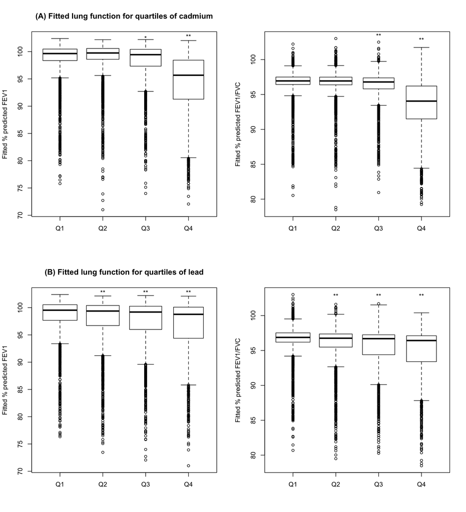

**Description：**

Boxplots of lung function for quartiles of cadmium and quartiles of lead in adults (20 ≤age ≤ 79 years). It shows the distribution of percent predicted FEV1 and percent predicted FEV1/FVC across the quartiles of serum cadmium(A) or lead(B). (* P< 0.05 and ** P< 0.01 for comparison with Q1.)

For the quartiles of cadmium, percent predicted FEV1 and percent predicted FEV1/FVC were significantly lower in the 3rd and 4th quartiles. (percent predicted FEV1: P< 0.05, P< 0.01;percent predicted FEV1/FVC: P< 0.01)

For the quartiles of lead, all parameters demonstrated a decreased trend across the 2nd, 3rd and 4th quartiles.

## The Process of Ploting

#### Firstly, we need to obtain our Generalized Linear Model(GLM) for these variables and use models to have fitted values.

**Take percent predicted FEV1 as an example.**

```r
library(sjPlot)
##GLM was used to examine associations between variables of interest including AFMIN,BMXBMI,asthma,LBXCOT,OCP and ENQ090 and outcomes[Percent Predicted FEV1].

#GLM for percent predicted FEV1
glm1_fev1 <- svyglm(FEV1_percent_predicted ~ AFMIN + BMXBMI + asthma + LBXCOT + OCP + ENQ090,
                    design = subset(design.WTMEC2YR, ((tmp_blood$RIDAGEYR >= 20)
                                                      & (tmp_blood$RIDAGEYR <= 79)
                                                      & (!is.na(tmp_blood$asthma)))),
                    family = gaussian(link = "identity"), na.action = na.omit)
#Summary of our GLM
tab_model(glm1_fev1, show.stat = TRUE,show.se = T,collapse.ci = TRUE,pred.labels = c("Intercept", "AFMIN", "BMXBMI", "Asthma",
                  "LBXCOT", "OCP",
                  "ENQ090"),
  dv.labels = c("FEV1 GLM Model"),
  string.pred = "Coeffcient",
  p.style = "stars")
```

FEV1 GLM Model

Coeffcient

Estimates

std. Error

Statistic

Intercept

105.14 ***  
(103.33 – 106.95)

0.92

113.74

AFMIN

-0.82  
(-2.12 – 0.49)

0.66

-1.23

BMXBMI

-0.18 ***  
(-0.24 – -0.12)

0.03

-6.00

Asthma

-6.99 ***  
(-8.08 – -5.90)

0.56

-12.55

LBXCOT

-0.02 ***  
(-0.02 – -0.01)

0.00

-9.48

OCP

-0.42  
(-1.26 – 0.43)

0.43

-0.96

ENQ090

-9.08 ***  
(-11.90 – -6.27)

1.44

-6.33

Observations

10520

R<sup>2</sup> / R<sup>2</sup> adjusted

0.090 / -221.494

- p<0.05 ** p<0.01 *** p<0.001

```r
#Design for sampling
design.WTMEC2YR <- svydesign(ids = ~SDMVPSU, strata = ~SDMVSTRA, weights = ~WTMEC5YR, nest = TRUE, data = tmp_blood)

dsub <- subset(design.WTMEC2YR, ((tmp_blood$RIDAGEYR >= 20)
                                 & (tmp_blood$RIDAGEYR <= 79)
                                 & (!is.na(tmp_blood$asthma))))

data2 <- tmp_blood[which((tmp_blood$RIDAGEYR >= 20)
                         & (tmp_blood$RIDAGEYR <= 79)
                         & (!is.na(tmp_blood$asthma))), ]
#Prediction
pred_df_fev1 <- data.frame(SEQN = data1$SEQN[which(!is.na(data2$FEV1_percent_predicted)
                                                   & !is.na(data2$AFMIN)
                                                   & !is.na(data2$BMXBMI)
                                                   & !is.na(data2$asthma)
                                                   & !is.na(data2$LBXCOT)
                                                   & !is.na(data2$OCP)
                                                   & !is.na(data2$ENQ090))],
                           fev1_fitted = fitted(glm1_fev1))
```

#### Secondly, we can obtain model fitted FEV1 or FEV1/FVC against cadmium or lead quartile by t-test comparions with FEV1 or FEV1/FVC and quantiles for cadmium or lead to have marks on the plot.

**Take comparions with Q1 and Q2 of cadmium as an example.**

```r
##t test was used to compare lung function between the 2nd, 3rd or 4th quartiles and the 1st quartile.
#Q1 VS Q2
t.test(data1$fev1_fitted[which(data1$LBXBCD_q == 0)], data1$fev1_fitted[which(data1$LBXBCD_q == 1)])
```

```
##
##  Welch Two Sample t-test
##
## data:  data1$fev1_fitted[which(data1$LBXBCD_q == 0)] and data1$fev1_fitted[which(data1$LBXBCD_q == 1)]
## t = -1.46, df = 5390.4, p-value = 0.1443
## alternative hypothesis: true difference in means is not equal to 0
## 95 percent confidence interval:
##  -0.34972195  0.05116027
## sample estimates:
## mean of x mean of y
##  98.27142  98.42070
```

#### Lastly, we can fit boxplots of lung function [model fitted value] against quartiles for cadmium or lead.

**Still take model fitted FEV1 against quartiles for cadmium as an example.**

```r
##Change labels of 'LBXBCD_q'

#Change data format into numeric
tmp_blood$LBXBCD_q <- as.numeric(as.character(tmp_blood$LBXBCD_q))
#Replace LBXBCD_q with NA when LBXBCD is NA
tmp_blood$LBXBCD_q[which(is.na(tmp_blood$LBXBCD))] <- NA
#Set breaks
breaks=c(0,0.22,0.34,0.62,max(tmp_blood$LBXBCD[!is.na(tmp_blood$LBXBCD)]))
#Replace LBXBCD_q with "Q1" when LBXBCD is less than 0.22; "Q2" when LBXBCD is no less than 0.22 but less than 0.34;"Q3" when LBXBCD is no less than 0.34 but less than 0.62;"Q4" when LBXBCD is no less than 0.62
tmp_blood$LBXBCD_q=factor(cut(tmp_blood$LBXBCD,breaks,c('Q1','Q2','Q3','Q4')))

##Design for sampling
design.WTMEC2YR <- svydesign(ids = ~SDMVPSU, strata = ~SDMVSTRA, weights = ~WTMEC5YR, nest = TRUE, data = tmp_blood)
#Adults(20≤ age≤79 years)
dsub <- subset(design.WTMEC2YR, ((tmp_blood$RIDAGEYR >= 20)
                                 & (tmp_blood$RIDAGEYR <= 79)
                                 & (!is.na(tmp_blood$asthma))))
data1 <- tmp_blood[which((tmp_blood$RIDAGEYR >= 20)
                         & (tmp_blood$RIDAGEYR <= 79)
                         & (!is.na(tmp_blood$asthma))), ]
```

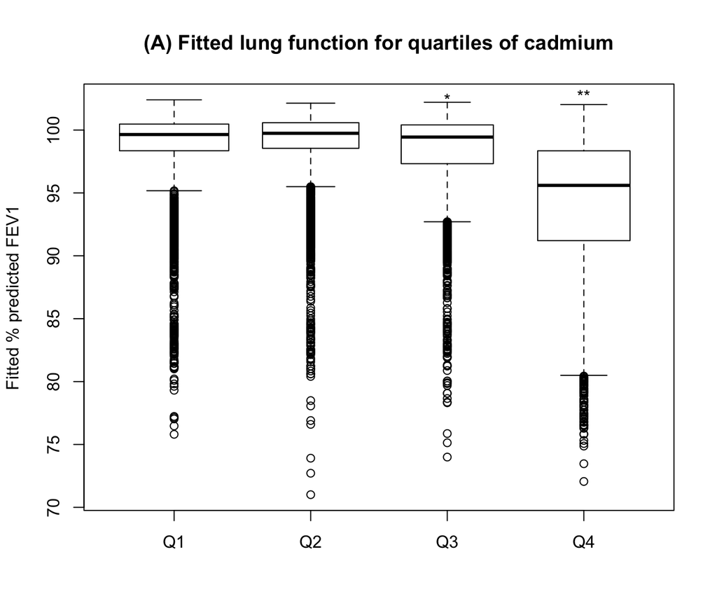

```r
#Lung function [model fitted value] against quartiles
svyboxplot(fev1_fitted ~ LBXBCD_q,
          design = subset(design.WTMEC2YR, ((tmp_blood$RIDAGEYR >= 20)
                                             & (tmp_blood$RIDAGEYR <= 79)
                                             & (!is.na(tmp_blood$asthma))
                                             & (!is.na(tmp_blood$LBXBCD_q)))),
           all.outliers = TRUE, na.rm = TRUE, varwidth = TRUE,
           ylab = "Fitted % predicted FEV1", main = "(A) Fitted lung function for quartiles of cadmium")
text(x = 3.0, y = 102.7, labels = "*")
text(x = 4.0, y = 103, labels = "**")
```

# Table 3

## Multivariate Analyses of Serum Level and Lung Function

### Stratified by current wheeze status

[output not shown]

**Description:**

Serum level of cadmium and lead and lung function in adults (20≤ age≤79 years), stratified by current wheeze status, with 95% confidence interval in parentheses. We use stars to show the level of significance. (* P< 0.05 and ** P< 0.01 for comparison with Q1.)

Among all participants, for every 1-unit increased in lg(serum cadmium), there were approximately 4.7, 4.4 and 3.5 decrease in percent predicted FEV1, percent predicted FEV1/FVC and FeNO, respectively.

## The Process of Getting Table 3

#### Firstly, we need to have the Generalized Linear Model(GLM) which describes the relationship between lg(serum cadmium) and Percent Predicted FEV1.

```r
##log10(cadmium)
#Associations with lung function were examined after log10 transforming the serum cadmium or lead.
tmp_blood$LBXBCD <- log10(tmp_blood$LBXBCD)

#Design for sampling
design.WTMEC2YR <- svydesign(ids = ~SDMVPSU, strata = ~SDMVSTRA, weights = ~WTMEC5YR, nest = TRUE, data = tmp_blood)
#Adults(20≤ age≤79 years)
dsub <- subset(design.WTMEC2YR, ((tmp_blood$RIDAGEYR >= 20)
                                 & (tmp_blood$RIDAGEYR <= 79)
                                 & (!is.na(tmp_blood$asthma))
                                 & (!is.na(tmp_blood$LBXBCD))))

##GLM which examined associations between log10(cadmium) and Percent Predicted FEV1 while other factors including AFMIN, BMXBMI, asthma, LBXCOT, OCP and ENQ090 being fixed
glm1 <- svyglm(FEV1_percent_predicted ~ AFMIN + BMXBMI + asthma + LBXCOT + OCP + ENQ090 + LBXBCD,
               design = subset(design.WTMEC2YR, ((tmp_blood$RIDAGEYR >= 20)
                                                 & (tmp_blood$RIDAGEYR <= 79)
                                                 & (!is.na(tmp_blood$asthma))
                                                 & (!is.na(tmp_blood$LBXBCD)))),
               family = gaussian(link = "identity"), na.action = na.omit)
#Summary of GLM
tab_model(glm1, show.stat = TRUE,show.se = T,collapse.ci = TRUE,pred.labels = c("Intercept", "AFMIN", "BMXBMI", "Asthma",
                  "LBXCOT", "OCP",
                  "ENQ090","LBXBCD"),
  dv.labels = c("FEV1 GLM Model"),
  string.pred = "Coeffcient",
  p.style = "stars")
```

FEV1 GLM Model

Coeffcient

Estimates

std. Error

Statistic

Intercept

103.12 ***  
(101.14 – 105.11)

1.01

101.84

AFMIN

-0.63  
(-1.88 – 0.63)

0.64

-0.98

BMXBMI

-0.20 ***  
(-0.25 – -0.14)

0.03

-6.86

Asthma

-6.58 ***  
(-7.66 – -5.50)

0.55

-11.91

LBXCOT

-0.01 ***  
(-0.01 – -0.01)

0.00

-4.49

OCP

-0.58  
(-1.43 – 0.27)

0.43

-1.33

ENQ090

-8.92 ***  
(-11.67 – -6.17)

1.40

-6.37

LBXBCD

-4.66 ***  
(-6.34 – -2.98)

0.86

-5.44

Observations

10510

R<sup>2</sup> / R<sup>2</sup> adjusted

0.099 / -224.518

- p<0.05 ** p<0.01 *** p<0.001

#### Secondly, we need to add interaction to the GLM.

```r
#Add interaction between LBXBCD and FeNO to the GLM
##GLM which examined associations between interaction of log10(cadmium) and FeNO and Percent Predicted FEV1 while other factors including AFMIN, BMXBMI, asthma, LBXCOT, OCP and ENQ090 being fixed
glm1 <- svyglm(FEV1_percent_predicted ~ AFMIN + BMXBMI + asthma + LBXCOT + OCP + ENQ090 + LBXBCD + feno + LBXBCD*feno,
               design = subset(design.WTMEC2YR, ((tmp_blood$RIDAGEYR >= 20)
                                                 & (tmp_blood$RIDAGEYR <= 79)
                                                 & (!is.na(tmp_blood$asthma))
                                                 & (!is.na(tmp_blood$LBXBCD)))),
               family = gaussian(link = "identity"), na.action = na.omit)

#Summary of new GLM
tab_model(glm1, collapse.ci = TRUE,
          pred.labels = c("Intercept", "AFMIN", "BMXBMI", "Asthma","LBXCOT","OCP","ENQ090","LBXBCD","FeNO3","LBXBCD*FeNO3"),
          dv.labels = c("FEV1 GLM Model with Interaction"),
          string.pred = "Coeffcient",
          p.style = "stars")
```

FEV1 GLM Model with Interaction

Coeffcient

Estimates

Intercept

103.98 ***  
(101.83 – 106.13)

AFMIN

-0.85  
(-2.00 – 0.30)

BMXBMI

-0.22 ***  
(-0.28 – -0.16)

Asthma

-6.23 ***  
(-7.51 – -4.94)

LBXCOT

-0.01 **  
(-0.01 – -0.00)

OCP

-0.53  
(-1.37 – 0.31)

ENQ090

-8.21 ***  
(-11.09 – -5.32)

LBXBCD

-4.47 ***  
(-6.38 – -2.55)

FeNO3

-0.82  
(-3.37 – 1.72)

LBXBCD*FeNO3

-0.00  
(-4.54 – 4.53)

Observations

9497

R<sup>2</sup> / R<sup>2</sup> adjusted

0.083 / -216.601

- p<0.05 ** p<0.01 *** p<0.001

# Table 4

## Multivariate Analyses of Serum Level and Lung Function

### Stratified by smoking status and current wheeze status

| Values | Serum.cadmium | Serum.Lead |
| --- | --- | --- |
| Measures | β(95% confidence interval) | β(95% confidence interval) |
| Never/former smokers |  |  |
| All participants (N = 11,712) |  |  |
| Percent predicted FEV1 | -3.18 (-4.95, -1.40) ** | -2.41 (-3.79, -1.04) ** |
| Percent predicted FVC | 0.17 (-1.31, 1.64) | 0.70 (-0.65, 2.06) |
| Percent predicted FEV1/FVC | -3.56 (-4.48, -2.63) ** | -2.90 (-3.63, -2.16) ** |
| FeNO3, ppb | -1.28 (-2.69, 0.14) | -0.20 (-1.70, 1.29) |
| Participants never wheeze (N = 10,359) |  |  |
| Percent predicted FEV1 | -2.52 (-4.15, -0.89) ** | -1.75 (-3.15, -0.34) * |
| Percent predicted FVC | 0.91 (-0.40, 2.21) | 1.00 (-0.43, 2.43) |
| Percent predicted FEV1/FVC | -3.51 (-4.45, -2.58) ** | -2.54 (-3.23, -1.86) ** |
| FeNO3, ppb | -2.11 (-3.73, -0.48) * | 0.07 (-1.31, 1.45) |
| Participants with current wheeze (N = 1,353) |  |  |
| Percent predicted FEV1 | -8.24 (-14.33, -2.15) ** | -8.74 (-12.70, -4.77) ** |
| Percent predicted FVC | -5.08 (-10.56, 0.40) | -2.34 (-5.49, 0.80) |
| Percent predicted FEV1/FVC | -4.32 (-7.98, -0.65) * | -6.11 (-9.06, -3.15) ** |
| FeNO3, ppb | 1.77 (-7.09, 10.63) | -0.12 (-7.77, 7.53) |
| Current smokers |  |  |
| All participants (N = 3,440) |  |  |
| Percent predicted FEV1 | -6.92 (-10.11, -3.73) ** | -4.13 (-6.59, -1.68) ** |
| Percent predicted FVC | -2.38 (-4.83, 0.07) | 1.19 (-1.13, 3.51) |
| Percent predicted FEV1/FVC | -5.09 (-6.97, -3.20) ** | -5.41 (-7.10, -3.71) ** |
| FeNO3, ppb | 0.64 (-0.84, 2.13) | 0.31 (-1.57, 2.20) |
| Participants never wheeze (N = 2,505) |  |  |
| Percent predicted FEV1 | -6.53 (-9.01, -4.05) ** | -1.20 (-4.15, 1.75) |
| Percent predicted FVC | -1.38 (-3.53, 0.77) | 2.81 (0.02, 5.60) |
| Percent predicted FEV1/FVC | -5.35 (-6.88, -3.82) ** | -3.74 (-5.38, -2.09) ** |
| FeNO3, ppb | 0.08 (-1.31, 1.47) | 1.10 (-0.82, 3.02) |
| Participants with current wheeze (N = 935) |  |  |
| Percent predicted FEV1 | -7.31 (-14.37, -0.26) * | -14.33 (-20.79, -7.88) ** |
| Percent predicted FVC | -4.91 (-9.66, -0.16) * | -4.62 (-11.12, 1.88) |
| Percent predicted FEV1/FVC | -3.82 (-8.44, 0.80) | -11.04 (-14.27, -7.81) ** |
| FeNO3, ppb | -0.71 (-6.05, 4.63) | -0.84 (-7.19, 5.52) |

**Description:**

Table 4 shows the serum level of cadmium and lead and lung function in adults, stratified by smoking status and current wheeze status. (* P < .05 and ** P < .01 for comparison with Q1.)

In never or former smokers, every 1-unit increment in log10(serum cadmium) was significantly associated with approximately 3.2 and 3.6 reduction in percent predicted FEV1 and percent predicted FEV1/FVC. Similar trends were found among never or former smokers with or without wheeze.

Current smokers showed the similar but more pronounced decline in lung function. For serum lead, we found that every 1-unit increment in log10(serum lead) was significantly associated with approximately 2.4 reduction in percent predicted FEV1 and 2.9 reduction in predicted FEV1/FVC among never or former smokers.

The significant decreasing pattern of lung function was also found in other strata of never or former smokers and among current smokers.

## The Process of Getting Table 4

#### Firstly, we apply svyglm function to the model, which fit a generalised linear model to data from the survey design, with inverse-probability weighting and design-based standard errors.

**Take participants who had never smoked or had smoked and who were not asthmatic as an example.**

```r
#GLM which examined associations between FEV1_percent_predicted and other factors
glm1 <- svyglm(FEV1_percent_predicted ~ AFMIN + BMXBMI + OCP + LBXCOT +  ENQ090 + LBXBCD,
               design = subset(design.WTMEC2YR, ((tmp_blood$RIDAGEYR >= 20)
                                                 & (tmp_blood$RIDAGEYR <= 79)
                                                 & (tmp_blood$smoking_status == "0")
                                                 & (tmp_blood$asthma == "0")
                                                 &
                                                (!is.na(tmp_blood$LBXBCD)))),
               family = gaussian(link = "identity"), na.action = na.omit)
#Summary of GLM
tab_model(glm1, show.stat = TRUE,show.se = T,collapse.ci = TRUE,pred.labels = c("Intercept","AFMIN","BMXBMI","OCP","LBXCOT","ENQ090","LBXBCD"),
   dv.labels = c("FEV1_percent_predicted GLM Model"),
   string.pred = "Coeffcient",
   p.style = "stars")
```

FEV1_percent_predicted GLM Model

Coeffcient

Estimates

std. Error

Statistic

Intercept

105.42 ***  
(103.06 – 107.78)

1.21

87.47

AFMIN

0.37  
(-0.72 – 1.45)

0.55

0.66

BMXBMI

-0.25 ***  
(-0.32 – -0.17)

0.04

-6.57

OCP

-0.02  
(-0.96 – 0.93)

0.48

-0.03

LBXCOT

-0.00  
(-0.01 – 0.00)

0.00

-1.40

ENQ090

-8.73 ***  
(-12.45 – -5.02)

1.90

-4.60

LBXBCD

-2.52 **  
(-4.15 – -0.89)

0.83

-3.03

Observations

7205

R<sup>2</sup> / R<sup>2</sup> adjusted

0.021 / -162.967

- p<0.05 ** p<0.01 *** p<0.001

```r
#confint(glm1, level = 0.95)

#GLM which examined associations between fvc_percent_predicted and  other factors
glm1 <- svyglm(fvc_percent_predicted ~  AFMIN + BMXBMI + OCP + LBXCOT+  ENQ090 + LBXBCD,
               design = subset(design.WTMEC2YR, ((tmp_blood$RIDAGEYR >= 20)
                                                 & (tmp_blood$RIDAGEYR <= 79)
                                                 & (tmp_blood$smoking_status == "0")
                                                 & (tmp_blood$asthma == "0")
                                                 & (!is.na(tmp_blood$LBXBCD)))),
               family = gaussian(link = "identity"), na.action = na.omit)
#Summary of GLM
tab_model(glm1, show.stat = TRUE,show.se = T,collapse.ci = TRUE,pred.labels = c("Intercept","AFMIN","BMXBMI","OCP","LBXCOT","ENQ090","LBXBCD"),
   dv.labels = c("fvc_percent_predicted GLM Model"),
   string.pred = "Coeffcient",
   p.style = "stars")
```

fvc_percent_predicted GLM Model

Coeffcient

Estimates

std. Error

Statistic

Intercept

111.71 ***  
(109.78 – 113.63)

0.98

113.56

AFMIN

-0.30  
(-1.39 – 0.78)

0.55

-0.54

BMXBMI

-0.31 ***  
(-0.38 – -0.25)

0.03

-9.44

OCP

0.64  
(-0.23 – 1.50)

0.44

1.44

LBXCOT

-0.00  
(-0.01 – 0.00)

0.00

-1.34

ENQ090

-5.97 **  
(-9.43 – -2.51)

1.77

-3.38

LBXBCD

0.91  
(-0.40 – 2.21)

0.67

1.36

Observations

7145

R<sup>2</sup> / R<sup>2</sup> adjusted

0.026 / -160.824

- p<0.05 ** p<0.01 *** p<0.001

```r
#confint(glm1, level = 0.95)

#GLM which examined associations between FEV1FVC_percent_predicted and  other factors
glm1 <- svyglm(FEV1FVC_percent_predicted ~  AFMIN + BMXBMI + OCP + LBXCOT + ENQ090 + LBXBCD,
               design = subset(design.WTMEC2YR, ((tmp_blood$RIDAGEYR >= 20)
                                                 & (tmp_blood$RIDAGEYR <= 79)
                                                 & (tmp_blood$smoking_status == "0")
                                                 & (tmp_blood$asthma == "0")
                                                 & (!is.na(tmp_blood$LBXBCD)))),
               family = gaussian(link = "identity"), na.action = na.omit,
               control = list(maxit = 50))
#Summary of GLM
tab_model(glm1, show.stat = TRUE,show.se = T,collapse.ci = TRUE,pred.labels = c("Intercept","AFMIN","BMXBMI","OCP","LBXCOT","ENQ090","LBXBCD"),
   dv.labels = c("FEV1FVC_percent_predicted GLM Model"),
   string.pred = "Coeffcient",
   p.style = "stars")
```

FEV1FVC_percent_predicted GLM Model

Coeffcient

Estimates

std. Error

Statistic

Intercept

93.84 ***  
(92.38 – 95.30)

0.74

126.11

AFMIN

0.72 *  
(0.13 – 1.30)

0.30

2.40

BMXBMI

0.05 *  
(0.01 – 0.09)

0.02

2.63

OCP

-0.58 **  
(-0.97 – -0.20)

0.20

-2.95

LBXCOT

-0.00  
(-0.00 – 0.00)

0.00

-0.81

ENQ090

-3.72 **  
(-5.92 – -1.53)

1.12

-3.33

LBXBCD

-3.51 ***  
(-4.45 – -2.58)

0.48

-7.37

Observations

7122

R<sup>2</sup> / R<sup>2</sup> adjusted

0.023 / -160.724

- p<0.05 ** p<0.01 *** p<0.001

```r
#confint(glm1, level = 0.95)

#GLM which examined associations between ENXTR1Q and  other factors
glm1 <- svyglm(ENXTR1Q ~ RIDAGEYR + RIAGENDR + RIDRETH1 + AFMIN + BMXBMI  + LBXCOT + OCP + ENQ090 + LBXBCD,
               design = subset(design.WTMEC2YR, ((tmp_blood$RIDAGEYR >= 20)
                                                 & (tmp_blood$RIDAGEYR <= 79)
                                                 & (tmp_blood$smoking_status == "0")
                                                 & (tmp_blood$asthma == "0")
                                                 & (!is.na(tmp_blood$LBXBCD)))),
               family = gaussian(link = "identity"), na.action = na.omit,
               control = list(maxit = 50))
#Summary of GLM
tab_model(glm1, show.stat = TRUE,show.se = T,collapse.ci = TRUE,pred.labels = c("Intercept","RIDAGEYR","RIAGENDR", "RIDRETH1","AFMIN","BMXBMI","OCP","LBXCOT","ENQ090","LBXBCD"),
   dv.labels = c("ENXTR1Q GLM Model"),
   string.pred = "Coeffcient",
   p.style = "stars")
```

ENXTR1Q GLM Model

Coeffcient

Estimates

std. Error

Statistic

(Intercept)

9.38 ***  
(7.20 – 11.56)

1.11

8.44

RIDAGEYR

0.10 ***  
(0.07 – 0.13)

0.01

7.09

RIAGENDR1

4.27 ***  
(3.23 – 5.30)

0.53

8.06

RIDRETH11

0.36  
(-0.95 – 1.66)

0.67

0.54

RIDRETH12

1.39 *  
(0.21 – 2.57)

0.60

2.30

RIDRETH13

1.32 *  
(0.21 – 2.43)

0.57

2.33

RIDRETH14

3.36 **  
(1.27 – 5.45)

1.07

3.15

AFMIN1

1.56 *  
(0.33 – 2.80)

0.63

2.48

BMXBMI

0.00  
(-0.05 – 0.06)

0.03

0.14

LBXCOT

-0.01 **  
(-0.01 – -0.00)

0.00

-3.55

OCP

-1.21 *  
(-2.22 – -0.20)

0.52

-2.35

ENQ0901

0.91  
(-1.75 – 3.57)

1.36

0.67

LBXBCD

-2.11 *  
(-3.73 – -0.48)

0.83

-2.55

Observations

7404

R<sup>2</sup> / R<sup>2</sup> adjusted

0.043 / -190.528

- p<0.05 ** p<0.01 *** p<0.001

```r
#confint(glm1, level = 0.95)
```

#### Secondly, we use svyglm function to explore the interaction about feno * Cd on fev1, fvc, fev1/fvc.

**Take participants who had never smoked or had smoked and who were not asthmatic as an example.**

```r
#GLM which examined associations between FEV1_percent_predicted and  other factors
glm1 <- svyglm(FEV1_percent_predicted ~ AFMIN + BMXBMI + OCP + LBXCOT +  ENQ090 + LBXBCD + feno + LBXBCD*feno,
               design = subset(design.WTMEC2YR, ((tmp_blood$RIDAGEYR >= 20)
                                                 & (tmp_blood$RIDAGEYR <= 79)
                                                 & (tmp_blood$smoking_status == "0")
                                                 & (tmp_blood$asthma == "0")
                                                 & (!is.na(tmp_blood$LBXBCD)))),
               family = gaussian(link = "identity"), na.action = na.omit)
#Summary of GLM
tab_model(glm1, show.stat = TRUE,show.se = T,collapse.ci = TRUE,pred.labels = c("Intercept","AFMIN","BMXBMI","OCP","LBXCOT","ENQ090","LBXBCD","feno","LBXBCD*feno"),
   dv.labels = c("FEV1_percent_predicted GLM Model"),
   string.pred = "Coeffcient",
   p.style = "stars")
```

FEV1_percent_predicted GLM Model

Coeffcient

Estimates

std. Error

Statistic

Intercept

105.98 ***  
(103.46 – 108.51)

1.29

82.40

AFMIN

0.14  
(-0.81 – 1.08)

0.48

0.28

BMXBMI

-0.26 ***  
(-0.34 – -0.19)

0.04

-6.72

OCP

0.00  
(-0.94 – 0.94)

0.48

0.00

LBXCOT

-0.00  
(-0.01 – 0.00)

0.00

-1.10

ENQ090

-8.98 ***  
(-12.55 – -5.40)

1.83

-4.92

LBXBCD

-2.45 *  
(-4.29 – -0.61)

0.94

-2.61

feno

-1.24  
(-4.23 – 1.76)

1.53

-0.81

LBXBCD*feno

-1.07  
(-5.66 – 3.52)

2.34

-0.46

Observations

6856

R<sup>2</sup> / R<sup>2</sup> adjusted

0.023 / -162.302

- p<0.05 ** p<0.01 *** p<0.001

```r
#confint(glm1, level = 0.95)

#GLM which examined associations between fvc_percent_predicted and other factors
glm1 <- svyglm(fvc_percent_predicted ~  AFMIN + BMXBMI + OCP + LBXCOT+  ENQ090 + LBXBCD + feno + LBXBCD*feno,
               design = subset(design.WTMEC2YR, ((tmp_blood$RIDAGEYR >= 20)
                                                 & (tmp_blood$RIDAGEYR <= 79)
                                                 & (tmp_blood$smoking_status == "0")
                                                 & (tmp_blood$asthma == "0")
                                                 & (!is.na(tmp_blood$LBXBCD)))),
               family = gaussian(link = "identity"), na.action = na.omit)
#Summary of GLM
tab_model(glm1, show.stat = TRUE,show.se = T,collapse.ci = TRUE,pred.labels = c("Intercept","AFMIN","BMXBMI","OCP","LBXCOT","ENQ090","LBXBCD","feno","LBXBCD*feno"),
   dv.labels = c("fvc_percent_predicted GLM Model"),
   string.pred = "Coeffcient",
   p.style = "stars")
```

fvc_percent_predicted GLM Model

Coeffcient

Estimates

std. Error

Statistic

Intercept

112.09 ***  
(110.00 – 114.17)

1.06

105.33

AFMIN

-0.54  
(-1.58 – 0.50)

0.53

-1.02

BMXBMI

-0.33 ***  
(-0.40 – -0.26)

0.03

-9.55

OCP

0.63  
(-0.26 – 1.51)

0.45

1.39

LBXCOT

-0.00  
(-0.01 – 0.00)

0.00

-0.96

ENQ090

-6.21 ***  
(-9.61 – -2.81)

1.73

-3.58

LBXBCD

0.66  
(-1.03 – 2.35)

0.86

0.76

feno

0.54  
(-2.22 – 3.29)

1.41

0.38

LBXBCD*feno

1.14  
(-3.14 – 5.43)

2.18

0.52

Observations

6802

R<sup>2</sup> / R<sup>2</sup> adjusted

0.028 / -160.182

- p<0.05 ** p<0.01 *** p<0.001

```r
#confint(glm1, level = 0.95)

#GLM which examined associations between FEV1FVC_percent_predicted and  other factors
glm1 <- svyglm(FEV1FVC_percent_predicted ~  AFMIN + BMXBMI + OCP + LBXCOT + ENQ090 + LBXBCD + feno + LBXBCD*feno,
               design = subset(design.WTMEC2YR, ((tmp_blood$RIDAGEYR >= 20)
                                                 & (tmp_blood$RIDAGEYR <= 79)
                                                 & (tmp_blood$smoking_status == "0")
                                                 & (tmp_blood$asthma == "0")
                                                 & (!is.na(tmp_blood$LBXBCD)))),
               family = gaussian(link = "identity"), na.action = na.omit,
               control = list(maxit = 50))
#Summary of GLM
tab_model(glm1, show.stat = TRUE,show.se = T,collapse.ci = TRUE,pred.labels = c("Intercept","AFMIN","BMXBMI","OCP","LBXCOT","ENQ090","LBXBCD","feno","LBXBCD*feno"),
   dv.labels = c("FEV1FVC_percent_predicted GLM Model"),
   string.pred = "Coeffcient",
   p.style = "stars")
```

FEV1FVC_percent_predicted GLM Model

Coeffcient

Estimates

std. Error

Statistic

Intercept

93.99 ***  
(92.47 – 95.51)

0.77

121.41

AFMIN

0.72 *  
(0.14 – 1.30)

0.30

2.43

BMXBMI

0.06 *  
(0.01 – 0.10)

0.02

2.68

OCP

-0.56 **  
(-0.96 – -0.17)

0.20

-2.80

LBXCOT

-0.00  
(-0.00 – 0.00)

0.00

-0.93

ENQ090

-3.73 **  
(-6.01 – -1.45)

1.16

-3.21

LBXBCD

-3.26 ***  
(-4.24 – -2.28)

0.50

-6.53

feno

-1.56 *  
(-3.06 – -0.06)

0.76

-2.04

LBXBCD*feno

-1.92  
(-4.44 – 0.61)

1.29

-1.49

Observations

6780

R<sup>2</sup> / R<sup>2</sup> adjusted

0.024 / -160.312

- p<0.05 ** p<0.01 *** p<0.001

```r
#confint(glm1, level = 0.95)
```

# e-Figure 1

## Odds Ratio Plot of Cadmium or Lead Level and Wheeze

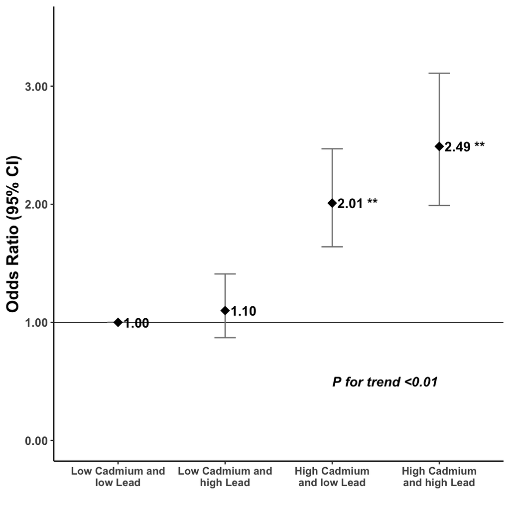

**Description:**

It shows the effect of serum cadmium and lead on whether had an asthma in adults, by presenting different odds ratios with their confidence intervals among different levels of metal_75. (* P< 0.05, **P< 0.01)

## The Process of Ploting

#### Firstly, we need to create a variable metal_75.

**Metal_75 including four levels:**

(1) Low Cadmium and low Lead;

(2) Low Cadmium and high Lead;

(3) High Cadmium and low Lead;

(4) High Cadmium and high Lead.

```r
##create a variable metal_75
#Replace metal_75 with NA when LBXBPB or LBXBCD is NA
tmp_blood$metal_75[is.na(tmp_blood$LBXBPB)|is.na(tmp_blood$LBXBCD)] <- NA

library(dplyr)

tmp_blood <- tmp_blood %>%
  mutate(metal_75 = ifelse(tmp_blood$LBXBCD <= 0.62,
#Low cadmium and low lead:When LBXBCD is no more than 0.62 and LBXBPB is no more than 2, replace metal_75 with 0
#Low cadmium and high lead:When LBXBCD is no more than 0.62 and LBXBPB is more than 2, replace metal_75 with 1
                           ifelse(tmp_blood$LBXBPB <= 2,0,1),
#High cadmium and low lead:When LBXBCD is more than 0.62 and LBXBPB is no more than 2, replace metal_75 with 2
#High cadmium and high lead:When LBXBCD is more than 0.62 and LBXBPB is more than 2, replace metal_75 with 3
                           ifelse(tmp_blood$LBXBPB <= 2,2,3)))

#Change data format into factor
tmp_blood$metal_75 <- as.factor(as.character(tmp_blood$metal_75))
```

#### Secondly, we need to fit the Generalized Linear Model(GLM) and calculate odds ratios.

```r
library(sjPlot)
#GLM for analyzing the influence of metal_75 on whether had an asthma, while other factors including RIDAGEYR, RIAGENDR, RIDRETH1, AFMIN, BMXBMI, MCQ300B, LBXCOT and OCP being fixed
glm1 <- svyglm(asthma ~ RIDAGEYR + RIAGENDR + RIDRETH1 + AFMIN + BMXBMI + MCQ300B + LBXCOT + OCP + metal_75,
               design = subset(design.WTMEC2YR, ((tmp_blood$RIDAGEYR >= 20)
                                                 & (tmp_blood$RIDAGEYR <= 79)
                                                 & (!is.na(tmp_blood$asthma))
                                                 & (!is.na(tmp_blood$metal_75)))),
               family = quasibinomial(), na.action = na.omit)

#Summary of GLM
tab_model(glm1,collapse.ci = TRUE,
          pred.labels = c("Intercept", "RIDAGEYR", "RIAGENDR", "RIDRETH1","AFMIN", "BMXBMI","MCQ300B","LBXCOT","OCP","metal_75"),
          dv.labels = c("Asthma GLM Model"),
          string.pred = "Coeffcient",
          p.style = "stars")
```

Asthma GLM Model

Coeffcient

Odds Ratios

(Intercept)

0.01 ***  
(0.00 – 0.02)

RIDAGEYR

1.00  
(1.00 – 1.01)

RIAGENDR1

0.70 ***  
(0.62 – 0.79)

RIDRETH11

0.58 ***  
(0.47 – 0.72)

RIDRETH12

0.81 *  
(0.67 – 0.97)

RIDRETH13

0.83 *  
(0.73 – 0.96)

RIDRETH14

0.95  
(0.73 – 1.23)

AFMIN1

1.45 ***  
(1.26 – 1.67)

BMXBMI

1.05 ***  
(1.04 – 1.06)

MCQ300B1

2.68 ***  
(2.35 – 3.04)

LBXCOT

1.00 ***  
(1.00 – 1.00)

OCP

1.78 ***  
(1.53 – 2.07)

metal_751

2.90 *  
(1.17 – 7.19)

metal_752

0.00 ***  
(0.00 – 0.00)

metal_753

6.12 ***  
(2.43 – 15.40)

Observations

12720

R<sup>2</sup> / R<sup>2</sup> adjusted

0.102 / -325.318

- p<0.05 ** p<0.01 *** p<0.001

```r
#Odds ratio
tab_df(data.frame(exp(cbind("Odds ratio" = coef(glm1), confint.default(glm1, level = 0.95)))))
```

| Row | Odds.ratio | X2.5.. | X97.5.. |
| --- | --- | --- | --- |
| (Intercept) | 0.01 | 0.00 | 0.02 |
| RIDAGEYR | 1.00 | 1.00 | 1.01 |
| RIAGENDR1 | 0.70 | 0.62 | 0.79 |
| RIDRETH11 | 0.58 | 0.47 | 0.72 |
| RIDRETH12 | 0.81 | 0.67 | 0.97 |
| RIDRETH13 | 0.83 | 0.73 | 0.96 |
| RIDRETH14 | 0.95 | 0.73 | 1.23 |
| AFMIN1 | 1.45 | 1.26 | 1.67 |
| BMXBMI | 1.05 | 1.04 | 1.06 |
| MCQ300B1 | 2.68 | 2.35 | 3.04 |
| LBXCOT | 1.00 | 1.00 | 1.00 |
| OCP | 1.78 | 1.53 | 2.07 |
| metal_751 | 2.90 | 1.17 | 7.19 |
| metal_752 | 0.00 | 0.00 | 0.00 |
| metal_753 | 6.12 | 2.43 | 15.40 |

#### Lastly, we can plot different odds ratios among different levels of metal_75.

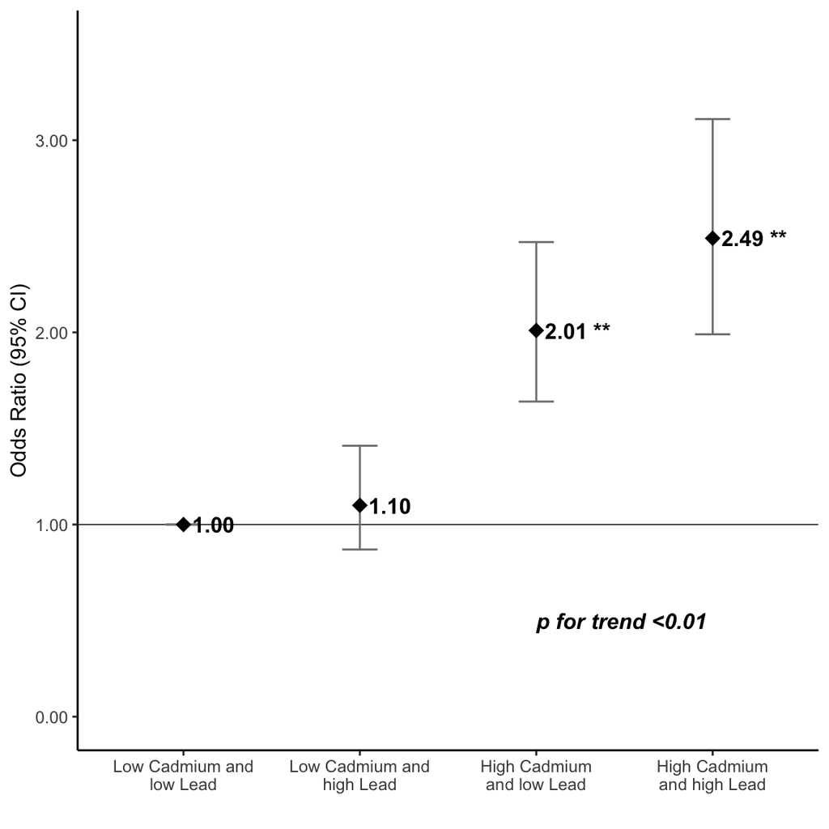

```r
library(ggplot2)
library(ggrepel)
library(stringr)
library(gridExtra)

#Confidence interval for odds radios
od1 <- data.frame(boxOdds = c(1.00, 1.10, 2.01, 2.49),
                  boxCIlow = c(1.00, 0.87, 1.64, 1.99),
                  boxCIhigh = c(1.00, 1.41, 2.47, 3.11))

#Set labels for ploting
boxLabels <- c("Low Cadmium and low Lead",
                         "Low Cadmium and high Lead",
                         "High Cadmium and low Lead",
                         "High Cadmium and high Lead")
rownames(od1) <- boxLabels

#Ploting
p <- ggplot(od1, aes(y = boxOdds, x = rownames(od1)))+geom_hline(aes(yintercept = 1.0), size = .25, linetype = "solid")+geom_errorbar(aes(ymax = boxCIhigh, ymin = boxCIlow), size = .5, width = .2, color = "gray50")+geom_point(size = 3.5, color = "black", shape = 18)

#Set the background,axis x,axis y of the graph
p <- p+scale_y_continuous("Odds Ratio (95% CI)",breaks = seq(0.00, 3.00), labels = c("0.00", "1.00", "2.00", "3.00"), limits = c(0.00, 3.50))+scale_x_discrete(" ",labels = function(x) str_wrap(x, width = 15), limits = boxLabels)+theme(axis.title.y = element_text(family = "", size = 14, face = "bold"),axis.text.y = element_text(family = "", size = 10, face = "bold"),panel.grid.minor = element_blank())+theme_classic()

#Add texts to the graph
p+annotate(geom = "text", y = 0.5, x = 3,label = "p for trend <0.01", size = 4, hjust = 0, fontface = 4)+geom_text(aes(label = c("1.00", "1.10", "2.01 **", "2.49 **")), hjust = 0, nudge_x = 0.05, size = 4, fontface = "bold")
```

# e-Figure 2

## Boxplots of Cadmium or Lead Level

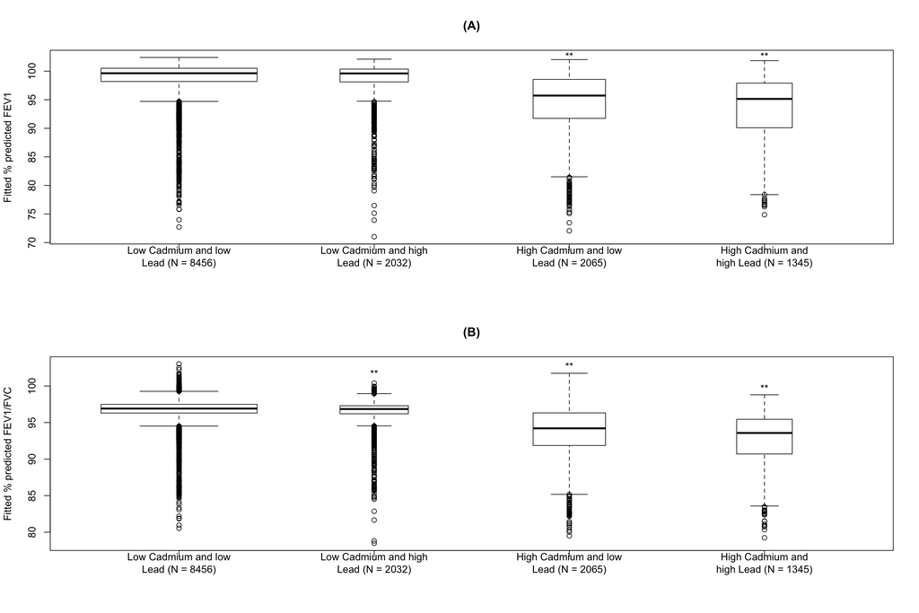

**Description：**

(A) and (B) are boxplots of adults’ lung function in different serum levels of cadmium and lead. It shows different distribution of percent predicted FEV1 and percent predicted FEV1/FVC under different levels of serum cadmium and lead. (* P< 0.05, **P< 0.01)

In this analysis of relationship between serum cadmium or lead and lung function, serum cadmium and lead demonstrated a synergistic effect on the reduction of percent predicted FEV1 and percent predicted FEV1/FVC.

## The Prcess of Ploting

#### Firstly, we need to fit Generalized Linear Model(GLM) for FEV1, FVC, FEV1/FVC and FeNO.

**Take the fitting model of FEV1 as an example.**

```r
library(sjPlot)
#GLM examined associations between Percent Predicted FEV1 and whether having an asthma while other factors including AFMIN, BMXBMI, LBXCOT, OCP and ENQ090 being fixed
glm1_fev1 <- svyglm(FEV1_percent_predicted ~ AFMIN + BMXBMI + asthma + LBXCOT + OCP + ENQ090,
                    design = subset(design.WTMEC2YR, ((tmp_blood$RIDAGEYR >= 20)
                                                      & (tmp_blood$RIDAGEYR <= 79)
                                                      & (!is.na(tmp_blood$asthma)))),
                    family = gaussian(link = "identity"), na.action = na.omit)

#Summary of GLM
tab_model(glm1_fev1, show.stat = TRUE,show.se = T,collapse.ci = TRUE,pred.labels = c("Intercept", "AFMIN", "BMXBMI", "Asthma",
                  "LBXCOT", "OCP",
                  "ENQ090"),
  dv.labels = c("FEV1 GLM"),
  string.pred = "Coeffcient",
  p.style = "stars")
```

FEV1 GLM

Coeffcient

Estimates

std. Error

Statistic

Intercept

105.14 ***  
(103.33 – 106.95)

0.92

113.74

AFMIN

-0.82  
(-2.12 – 0.49)

0.66

-1.23

BMXBMI

-0.18 ***  
(-0.24 – -0.12)

0.03

-6.00

Asthma

-6.99 ***  
(-8.08 – -5.90)

0.56

-12.55

LBXCOT

-0.02 ***  
(-0.02 – -0.01)

0.00

-9.48

OCP

-0.42  
(-1.26 – 0.43)

0.43

-0.96

ENQ090

-9.08 ***  
(-11.90 – -6.27)

1.44

-6.33

Observations

10520

R<sup>2</sup> / R<sup>2</sup> adjusted

0.090 / -221.494

- p<0.05 ** p<0.01 *** p<0.001

#### Secondly, we can get our predictions using our fitted models.

**Take the fitting model of FEV1 as an example again.**

```r
#Prediction
pred_df_fev1 <- data.frame(SEQN = data1$SEQN[which(!is.na(data1$FEV1_percent_predicted)
                                                   & !is.na(data1$AFMIN)
                                                   & !is.na(data1$BMXBMI)
                                                   & !is.na(data1$asthma)
                                                   & !is.na(data1$LBXCOT)
                                                   & !is.na(data1$OCP)
                                                   & !is.na(data1$ENQ090))],
                           fev1_fitted_75 = fitted(glm1_fev1))
```

#### Then, we move to obtain t-test of fitted values under different levels of metal_75 to ensure the significance.

**Take the fitting value of FEV1 as an example again.**

```r
#Low cadmium and low lead vs Low cadmium and high lead
t.test(data1$fev1_fitted_75[which(data1$metal_75 == "0")], data1$fev1_fitted_75[which(data1$metal_75 == "1")])
```

```
##
##  Welch Two Sample t-test
##
## data:  data1$fev1_fitted_75[which(data1$metal_75 == "0")] and data1$fev1_fitted_75[which(data1$metal_75 == "1")]
## t = 0.6176, df = 2198.3, p-value = 0.5369
## alternative hypothesis: true difference in means is not equal to 0
## 95 percent confidence interval:
##  -0.1489510  0.2859013
## sample estimates:
## mean of x mean of y
##  98.24840  98.17992
```

#### Lastly,we can do ploting.

**Still take the fitting model of FEV1 as an example.**

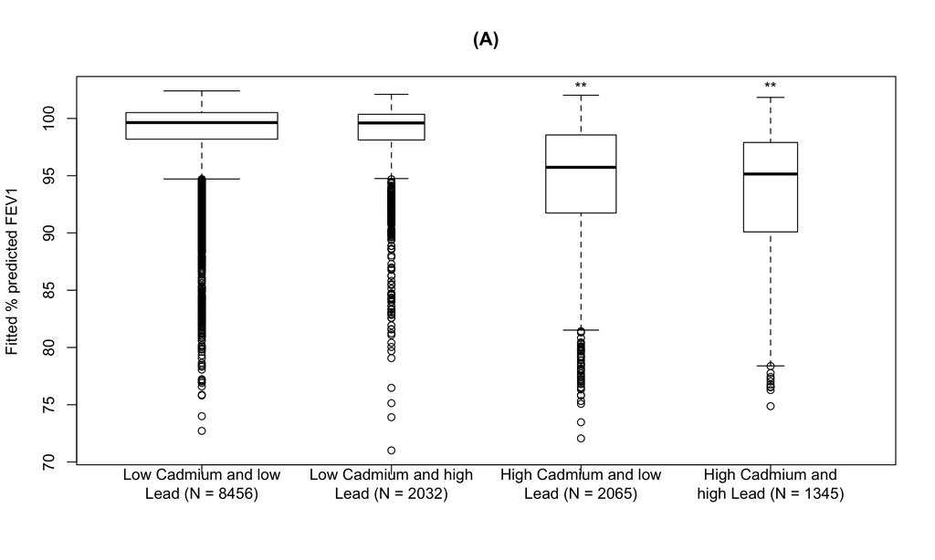

```r
#Core wrapping function
wrap.it <- function(x, len)
{
  sapply(x, function(y) paste(strwrap(y, len),
                              collapse = "\n"),
         USE.NAMES = FALSE)
}

#Call this function with a list or vector
wrap.labels <- function(x, len)
{
  if (is.list(x))
  {
    lapply(x, wrap.it, len)
  } else {
    wrap.it(x, len)
  }
}

labels <- c("Low Cadmium and low Lead (N = 8456)",
            "Low Cadmium and high Lead (N = 2032)",
            "High Cadmium and low Lead (N = 2065)",
            "High Cadmium and high Lead (N = 1345)")

wr.lap <- wrap.labels(labels, 21)

#Design for sampling
#Adults(20≤ age≤79 years)
design.WTMEC2YR <- svydesign(ids = ~SDMVPSU, strata = ~SDMVSTRA, weights = ~WTMEC5YR, nest = TRUE, data = tmp_blood)
dsub <- subset(design.WTMEC2YR, ((tmp_blood$RIDAGEYR >= 20)
                                 & (tmp_blood$RIDAGEYR <= 79)
                                 & (!is.na(tmp_blood$asthma))
                                 & (!is.na(tmp_blood$metal_75))))

#Boxplot
p <- svyboxplot(fev1_fitted_75 ~ metal_75,
                design = subset(design.WTMEC2YR, ((tmp_blood$RIDAGEYR >= 20) & (tmp_blood$RIDAGEYR <= 79) & (!is.na(tmp_blood$asthma)) & (!is.na(tmp_blood$metal_75)))),
                all.outliers = TRUE,
                na.rm = TRUE,
                varwidth = TRUE,
                names = wr.lap,
                ylab = "Fitted % predicted FEV1", main = "(A)")

#Add text to show significance
text(x = 3.0, y = 103, labels = "**")
text(x = 4.0, y = 103, labels = "**")
```